# Different Modes of Transportation in the United States: Report

Lily Claire Gibson-Grossmann

2024-10-21

# 1 Introduction

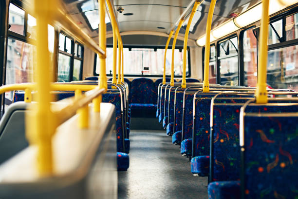

## 1.1 Topic of Interest

This dataset provides a breakdown of commuters to work in the United States, highlighting five primary modes of transportation to work: Car/Truck/Van (Drove Alone), Car/Truck/Van (Carpooled), Walking, Taxicab/Motorcycle/Bicycle/Other, and Working From Home. I am interested in examining the trends in commuting methods over time, specifically looking at the rise of remote work and the trends of different modes of transportation in the United States.

The COVID-19 pandemic made a shift to working from home; I am curious to explore how this trend developed both before and after the pandemic. In addition, I am curious how different modes of transportation for commuting to work has changed over the years. Non-private transportation in the U.S. has limited availability, as the US primarily uses private transportation (individual cars). However, there are many benefits to using other modes of transit and I am curious if the US is diversifying our modes of transit in regard to commutes to work.

By examining these trends and correlations, we will gain insights into how commuting has evolved in the U.S. in the context of working from home and different modes of transportation.

## 1.2 Key Questions

In the U.S., how did the work-from-home (WFH) trend develop before COVID-19, and how has it evolved post-pandemic?

What was the trend of different modes of transportation in general leading up to the pandemic, and how has it shifted since the pandemic in the U.S.?

How have subcategories of different modes of transportation, such as carpooling or walking, changed over time in the U.S.?

## 1.3 Data Description

The data in this table is sourced from the U.S. Census Bureau through the American Community Survey (ACS). The data is collected from the ACS one-year estimates, which are collected annually throughout each year. By using one-year estimates instead of the alternative five-year estimates from the ACS, we get a better understanding of the current population. The sample data from each year is representative of the U.S. population, more specifically are applicable to geographies with a population of 65,000 people or more. This data might not be as representative of geographies with less than 65,000 people, and these samples are used for general U.S. population estimations.

The ASC data is collected continuously throughout the year using multiple ways. Some of these methods are sending out surveys via mail, conducting phone interviews, and using in-person visits to gather information (data) from a sample of households. The U.S. Census Bureau did not release the 2020 ACS 1-year estimates for this table due to the COVID-19 pandemic. The data was too low of quality to be considered, so instead the Census Bureau released experimental estimates in 2020 for a limited number of tables, which was not included in this table I chose. Therefore, we do not have data for the year 2020 in our dataset.

The dataset consists of 37 columns, giving a breakdown of commuters by their mode of transportation, which is the primary focus of this analysis. The data further subdivides each transportation mode based on the number of cars available to the commuter (e.g., no car, one car, etc.). We will not be considering these variables of the dataset given the questions we are exploring, but these additional variables could offer context for understanding the transportation choices of different commuter groups in future analysis.

**Sources**

- [Source: US Census Bureau](https://www.census.gov/programs-surveys/acs/data/experimental-data.html)
- [Source: U.S. Bureau of Labor Statistics](https://www.bls.gov/lau/acsqa.htm)

## 1.4 Relevant Variables

**Key**

- Total: Total Sample Collected
- CTV DA T: Car/Truck/Van (Drove Alone) Total
- CTV C T: Car/Truck/Van (Carpooled) Total
- W T: Walked Total
- TMBO T: Taxicab/Motorcycle/Bicycle/Other Total
- WFH T: Worked From Home Total

*Note: The term “Total” signifies the aggregate number of individuals represented in the dataset for each respective year.*

## 1.5 Detailed Code

To see the R code used for this project, use the ‘Code’ button at the top right corner to download the .Rmd file. This file contains the code used to knit this report. There is code snippets included throughout the report due to the requirements of the report, but this does not include all of the code used to knit this report. I’ve chosen to exclude many snippets of code (using echo=FALSE) to make the report cleaner, easier to read, and understand; if there is code you want to reference, please use the .Rmd file.

# 2 Data Cleaning/Tidying

## 2.1 Load Packages

I will start by loading the essential packages in R. I will use the tidyverse package for the data cleaning process. Tidyverse allows for easier data handling, cleaning, and tidying.

```r
library(tidyverse)
```

## 2.2 Read in CSV Files & Add ‘Year’ Column

Next, I will import my dataset, which is organized by year. As a result, I had to download a separate CSV file for each year, spanning from 2010 to 2023.

Since the individual datasets lack a year identifier, I will create an additional column to represent the year for each dataset. This step is necessary when we join the datasets, as it will allow us to differentiate the year associated with each entry.

Additionally, in this step I will limit the rows we are considering. Due to how the original datasets are framed, we have rows that contain white space and can be disregarded. Ultimately, the second row is the only row with the figures we will take into consideration.

```r
data_2023 <- read.csv("Transportation_Data_2023.csv")
data_2023$Year <- 2023
data_2023 <- data_2023[2,]
data_2022 <- read.csv("Transportation_Data_2022.csv")
data_2022$Year <- 2022
data_2022 <- data_2022[2,]
data_2021 <- read.csv("Transportation_Data_2021.csv")
```

This pattern of loading in data and adding a column for the year continues for the remaining data sets showing the years 2010 - 2021. In order to preserve space, I will not include this code in the report.

## 2.3 View Original Columns

As previously stated, we will be limiting the dataset to the relevant columns we are considering given our set of questions for this analysis. To better understand the original data, below is a list of all of the column names provided in the original datasets.

```r
names(data_2023)
```

```
##  [1] "Label..Grouping."
##  [2] "Total."
##  [3] "Total...No.vehicle.available"
##  [4] "Total...1.vehicle.available"
##  [5] "Total...2.vehicles.available"
##  [6] "Total...3.or.more.vehicles.available"
##  [7] "Total...Car..truck..or.van...drove.alone."
##  [8] "Total...Car..truck..or.van...drove.alone...No.vehicle.available"
##  [9] "Total...Car..truck..or.van...drove.alone...1.vehicle.available"
## [10] "Total...Car..truck..or.van...drove.alone...2.vehicles.available"
## [11] "Total...Car..truck..or.van...drove.alone...3.or.more.vehicles.available"
## [12] "Total...Car..truck..or.van...carpooled."
## [13] "Total...Car..truck..or.van...carpooled...No.vehicle.available"
## [14] "Total...Car..truck..or.van...carpooled...1.vehicle.available"
## [15] "Total...Car..truck..or.van...carpooled...2.vehicles.available"
```

[output cut: 22 more lines]

## 2.4 Edit Column Names

The columns in the dataset represent the same figures across different years, but some of them have slightly varied names between earlier and more recent datasets. For example, below is a comparison of the same column from the 2018 and 2023 data; it is clear there is slight variation as to how the column is named, even though these columns represent the same figures.

```r
names(data_2023[32])
```

```
## [1] "Total...Worked.from.home."
```

```r
names(data_2018[32])
```

```
## [1] "Total...Worked.at.home."
```

To ensure our data can be integrated, I will standardize the column names, ensuring they are consistent across all years.

Given that the original column names are lengthy and not intuitively clear, I will create a key to represent each column as follows. This key focuses on the variables of our interest.

**Key**

- Total: Total Sample Collected
- CTV DA T: Car/Truck/Van (Drove Alone) Total
- CTV C T: Car/Truck/Van (Carpooled) Total
- W T: Walked Total
- TMBO T: Taxicab/Motorcycle/Bicycle/Other Total
- WFH T: Worked From Home Total

*Note: The term “Total” signifies the aggregate number of individuals represented in the dataset for each respective year.*

```r
data_2023 <- data_2023 %>% rename(
  'Total' = 'Total.',
  'CTV DA T' = 'Total...Car..truck..or.van...drove.alone.',
  'CTV C T' = 'Total...Car..truck..or.van...carpooled.',
  'W T' = 'Total...Walked.',
  'TMBO T' = 'Total...Taxicab..motorcycle..bicycle..or.other.means.',
  'WFH T' = 'Total...Worked.from.home.'
)
data_2022 <- data_2022 %>% rename(
  'Total' = 'Total.',
  'CTV DA T' = 'Total...Car..truck..or.van...drove.alone.',
  'CTV C T' = 'Total...Car..truck..or.van...carpooled.',
  'W T' = 'Total...Walked.',
  'TMBO T' = 'Total...Taxicab..motorcycle..bicycle..or.other.means.',
  'WFH T' = 'Total...Worked.from.home.'
)
```

This pattern of changing the column names to be universal across all datasets continues for the remaining data sets showing the years 2010 - 2021. In order to preserve space, I will not include this code in the report.

## 2.5 Data Subsetting

There are 37 columns that are provided in the original dataset. The final dataset should only include the variables of our interest, which are those that are stated above in the key. The next step is to subset the data to the columns provided in the key (previous step). This will ensure our datasets are joined correctly when creating the aggregated dataset.

```r
data_2023 <- data_2023 %>% select('Total',
                        'CTV DA T',
                        'CTV C T',
                        'W T',
                        'TMBO T',
                        'WFH T',
                        'Year')

data_2022 <- data_2022 %>% select('Total',
                        'CTV DA T',
                        'CTV C T',
                        'W T',
                        'TMBO T',
                        'WFH T',
                        'Year')
```

This pattern of subsetting the data continues for the remaining data sets showing the years 2010 - 2021. In order to preserve space, I will not include this code in the report.

## 2.6 Joining Data

The next step is to join our datasets to create one centralized dataset. Using the ‘rbind’ R function, we can bind all of the datasets ranging from 2010 to 2023 (excluding 2020). Below is the final aggregated data set shown.

```r
data <- rbind(data_2010, data_2011, data_2012, data_2013, data_2014, data_2015, data_2016, data_2017, data_2018, data_2019, data_2021, data_2022, data_2023)
data
```

|  | Total | CTV DA T | CTV C T | W T | TMBO T | WFH T | Year |
| --- | --- | --- | --- | --- | --- | --- | --- |
| 2 | 135,609,986 | 104,549,674 | 13,153,874 | 3,290,953 | 2,292,402 | 5,640,855 | 2010 |
| 21 | 136,854,798 | 105,303,940 | 13,271,633 | 3,350,796 | 2,367,160 | 5,704,705 | 2011 |
| 22 | 139,482,182 | 107,138,660 | 13,563,189 | 3,427,744 | 2,515,977 | 5,885,340 | 2012 |
| 23 | 141,589,579 | 108,963,259 | 13,274,746 | 3,438,216 | 2,637,402 | 5,988,852 | 2013 |
| 24 | 144,456,245 | 111,185,254 | 13,368,899 | 3,455,032 | 2,671,756 | 6,271,784 | 2014 |
| 25 | 146,920,523 | 113,199,758 | 13,238,218 | 3,551,816 | 2,646,313 | 6,644,069 | 2015 |
| 26 | 148,906,811 | 114,402,086 | 13,456,085 | 3,481,873 | 2,658,562 | 7,372,631 | 2016 |
| 27 | 151,339,299 | 116,355,953 | 13,491,862 | 3,447,641 | 2,734,196 | 7,778,670 | 2017 |
| 28 | 153,149,746 | 117,553,927 | 13,772,254 | 3,431,422 | 2,830,378 | 8,050,253 | 2018 |
| 29 | 155,438,782 | 118,757,588 | 13,782,971 | 3,518,568 | 2,946,863 | 8,771,015 | 2019 |

[output cut: 3 more lines]

## 2.7 Change Column Type

We need to ensure our data is stored as integers. Currently, the data is stored as characters and has non-numerical characters, such as commas, within the strings. We can see this by using the ‘class’ R function for any one of our columns; the class that is returned is ‘character’ (not an integer).

```r
class(data$Total)
```

```
## [1] "character"
```

```r
class(data$`WFH T`)
```

```
## [1] "character"
```

The ‘as.integer’ R function will convert the figures from strings to integers. There will be an error, however, due to the presence of commas in the string. To overcome this error, the gsub R function will delete any comma in the string by replacing the comma with an empty value (““). This step is necessary for analysis.

```r
data$Total <- as.integer(gsub(",", "", data$Total))
data$`CTV DA T` <- as.integer(gsub(",", "", data$`CTV DA T`))
data$`CTV C T` <- as.integer(gsub(",", "", data$`CTV C T`))
data$`W T` <- as.integer(gsub(",","", data$`W T`))
data$`TMBO T` <- as.integer(gsub(",", "", data$`TMBO T`))
data$`WFH T` <- as.integer(gsub(",", "", data$`WFH T`))
data$Year <- as.integer(data$Year)
view(data)
```

## 2.8 Final Table

Below is the final table after tidying and joining the original datasets. This new dataset contains integers so we can do analysis, has a year column so we can differentiate each entry, and is limited to only the columns we are interested in.

|  | Total | CTV DA T | CTV C T | W T | TMBO T | WFH T | Year |
| --- | --- | --- | --- | --- | --- | --- | --- |
| 2 | 135609986 | 104549674 | 13153874 | 3290953 | 2292402 | 5640855 | 2010 |
| 21 | 136854798 | 105303940 | 13271633 | 3350796 | 2367160 | 5704705 | 2011 |
| 22 | 139482182 | 107138660 | 13563189 | 3427744 | 2515977 | 5885340 | 2012 |
| 23 | 141589579 | 108963259 | 13274746 | 3438216 | 2637402 | 5988852 | 2013 |
| 24 | 144456245 | 111185254 | 13368899 | 3455032 | 2671756 | 6271784 | 2014 |
| 25 | 146920523 | 113199758 | 13238218 | 3551816 | 2646313 | 6644069 | 2015 |
| 26 | 148906811 | 114402086 | 13456085 | 3481873 | 2658562 | 7372631 | 2016 |
| 27 | 151339299 | 116355953 | 13491862 | 3447641 | 2734196 | 7778670 | 2017 |
| 28 | 153149746 | 117553927 | 13772254 | 3431422 | 2830378 | 8050253 | 2018 |
| 29 | 155438782 | 118757588 | 13782971 | 3518568 | 2946863 | 8771015 | 2019 |

[output cut: 3 more lines]

# 3 Analysis

## 3.1 Total Commute to Work Distribution Over Time

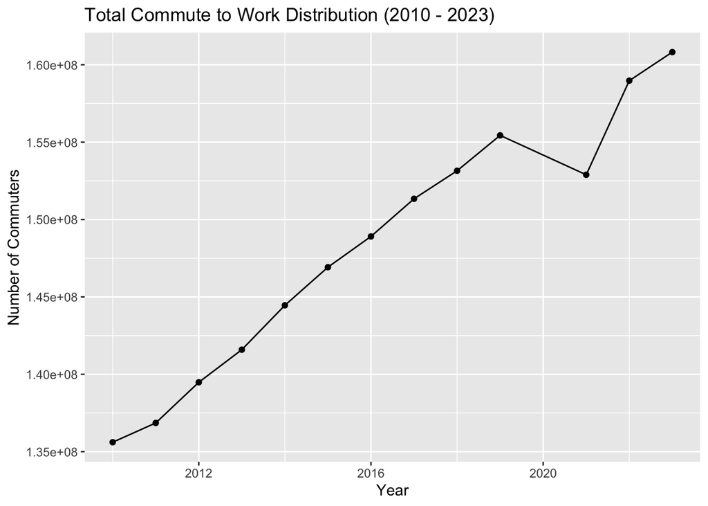

This graph shows the total number of commuters (e.g. the total sample) in the U.S. over time (2010 to 2023). The sample size for the number of commuters has grown over time, which is representative of the population growth in the urban cities (population of 65k people or more) in the U.S.. As urban cities have grown in the U.S., sample size is increased to more accurately represent the population.

[Source: US Census Bureau](https://www.census.gov/programs-surveys/acs/about/top-questions-about-the-survey.html)

## 3.2 Linear Model: Total Commute to Work Distribution Over Time

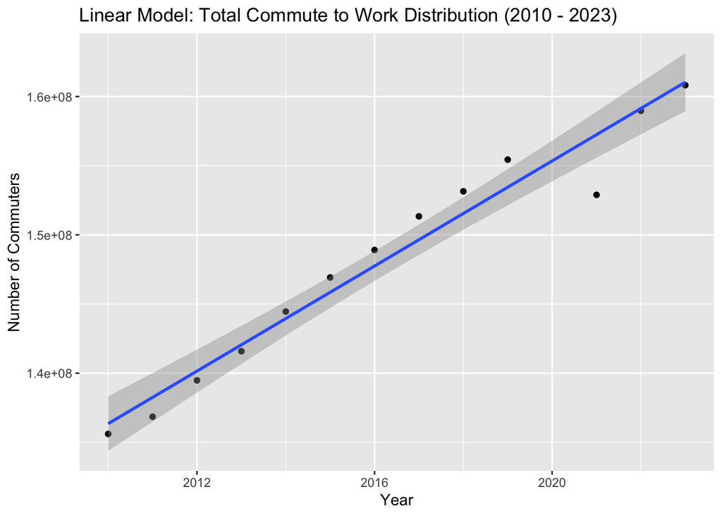

A linear regression line has been added using geom_smooth(method = “lm”) to illustrate the general trend in population changes over time. The shaded area around the line represents the 95% confidence interval, reflecting the uncertainty of the trend’s fit. From this linear model, we can again see that overall, there is a positive relationship between the total sample size and time. This shows that over time, the samples being drawn by the ACS is growing to more accurately reflect the U.S. population.

[Source: US Census Bureau](https://www.census.gov/programs-surveys/acs/about/top-questions-about-the-survey.html)

## 3.3 Car/Truck/Van (Drove Alone) Commute to Work Distribution

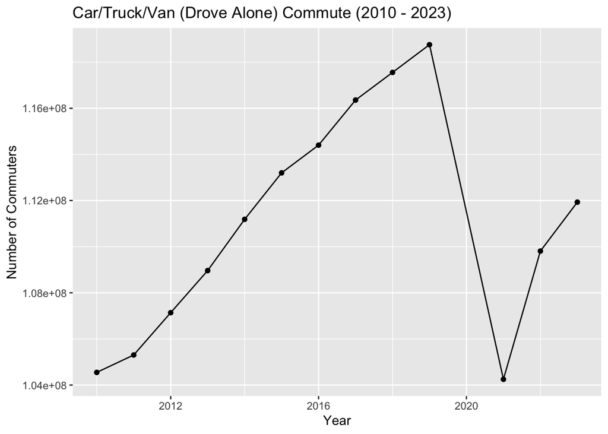

For the subset of commuters who used a car, truck, or van (driving alone) to commute to work, the number of commuters grew at a relatively steady rate over time. However, in 2021, there was a sharp decline due to the COVID-19 pandemic, as previously mentioned. The number of commuters doesn’t reach the peak it was at prior to the pandemic, indicating that after the pandemic less people are driving alone. This is likely due to work from home along with other different modes of transit growing during and after the pandemic, which will be seen in later analysis.

Correlation will help us understand the magnitude of the growth for the mode of transportation for the commute in relation to time (years). The closer to 1 (or -1), the stronger the relationship, indicating that mode of transport was heavily increasing (or decreasing) year by year. Inversely, the closer to 0 the correlation is indicates the weaker the relationship.

The overall correlation between these commuters and time (years) is relatively weak, with a correlation coefficient of 0.3752, indicating a small relationship between time and the growth of commuters. This weaker correlation is likely skewed by the significant drop in 2021.

```r
cor(data$`CTV DA T`, data$Year)
```

```
## [1] 0.3752721
```

To better understand the trend, accounting for the previously stated drop in 2021, the data can be divided into pre- and post-COVID periods. Before the pandemic, the correlation between commuters and time was very strong, with a coefficient of 0.9965. After the pandemic, the correlation remained strong at 0.9682. This shows a robust relationship between time and the number of car/truck/van (drove alone) commuters. Overall, the number of car/truck/van (drove alone) commuters in the U.S. has increased over time.

```r
pre_covid <- data %>% filter(data$Year < 2021)
post_covid <- data %>% filter(data$Year >= 2021)
cor(pre_covid$`CTV DA T`, pre_covid$Year)
```

```
## [1] 0.9965433
```

```r
cor(post_covid$`CTV DA T`, post_covid$Year)
```

```
## [1] 0.9682169
```

## 3.4 Car/Truck/Van (Carpooled) Commute to Work Distribution

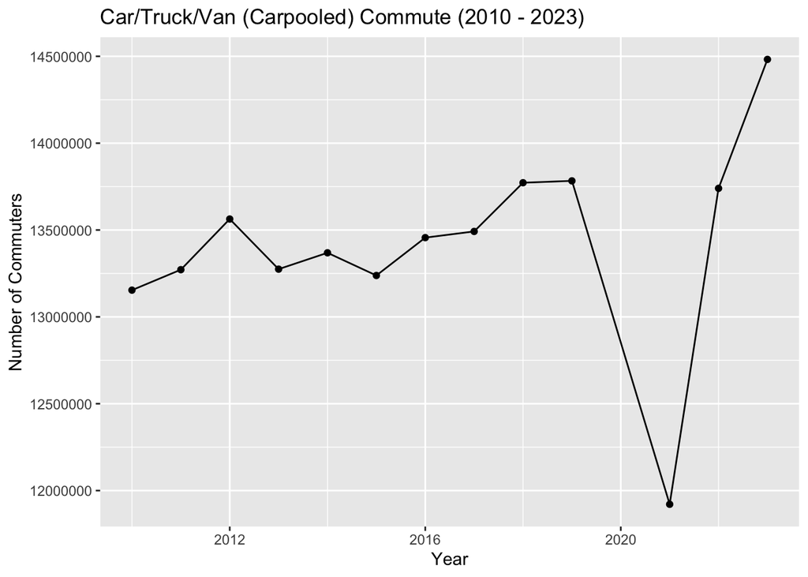

For the subset of commuters who used a car, truck, or van (carpooling) to commute to work, the number of commuters grew at a somewhat steady rate over time; we can see much more variability in the carpooled data versus the driving alone data. As previously mentioned, in 2021, there was a sharp decline due to the COVID-19 pandemic.

The overall correlation between these commuters and time (years) is weak, with a correlation coefficient of 0.2141. This indicates a small relationship between time and the growth of car/truck/van (carpooling) commuters over the whole time period (2010 - 2023).

```r
cor(data$`CTV C T`, data$Year)
```

```
## [1] 0.2141343
```

As previously stated, we can break our data into pre-COVID and post-COVID datasets to better understand the correlations. Before the pandemic, the correlation between commuters and time was moderately strong, with a coefficient of 0.7748. After the pandemic, the correlation grew in strength, rising to 0.9718. This shows that before the COVID-19 pandemic, the number of car/truck/van (carpooling) commuters in the U.S. was growing, and after the pandemic this mode of transportation has started increasing more heavily.

```r
cor(pre_covid$`CTV C T`, pre_covid$Year)
```

```
## [1] 0.7748086
```

```r
cor(post_covid$`CTV C T`, post_covid$Year)
```

```
## [1] 0.9717854
```

## 3.5 Walked Commute to Work Distribution

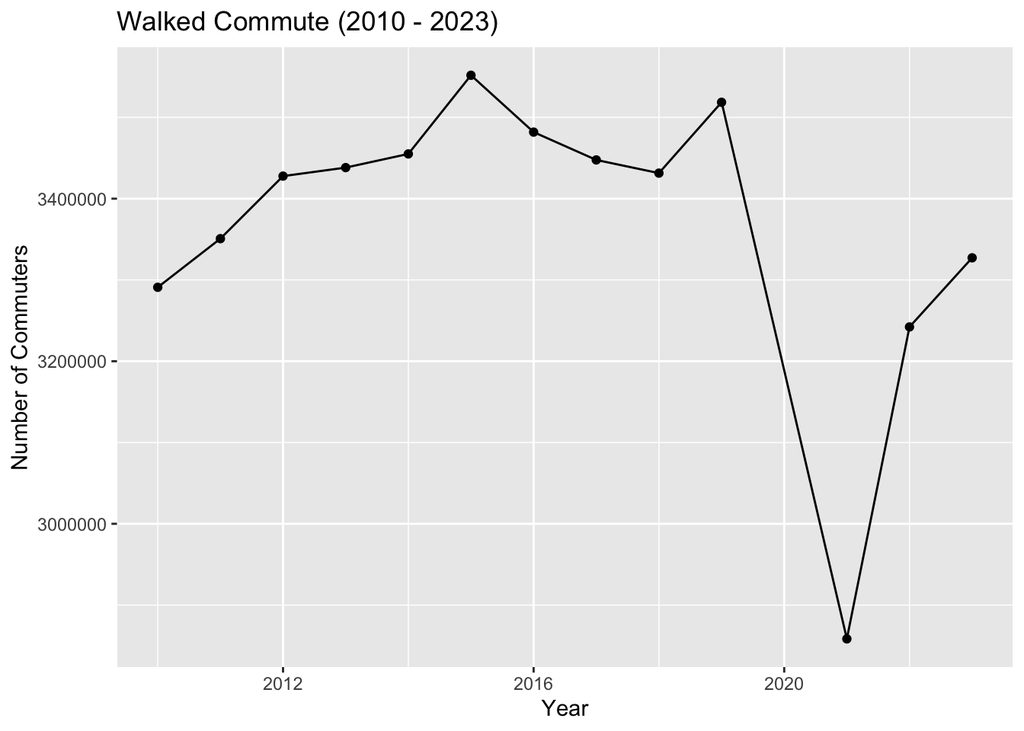

For the subset of commuters who walked to commute to work, the number of commuters grew at a somewhat steady rate over time. We can see some variability overall, with this mode of transportation decreasing some starting around 2015. As previously mentioned, in 2021, there was a sharp decline due to the COVID-19 pandemic. After the pandemic, we can see an increase in the trend start again, potentially indicating that after the pandemic, walking to work has been an increasing mode of transportation.

The overall correlation between these commuters and time (years) is weak, with a correlation coefficient of -0.3548, indicating a weak relationship between time and the growth of commuters between 2010 to 2023 (excluding 2020). The negative coefficient, in general, shows that as one variable increases, the other variable decreases. The negative correlation does not indicate a more strong/weak correlation, but instead shows if the correlation is positively or negatively associated.

```r
cor(data$`W T`, data$Year)
```

```
## [1] -0.3547618
```

Before the pandemic, the correlation between commuters and time was moderately strong, with a coefficient of 0.7159. After the pandemic, the correlation grew in strength, rising to 0.9385. This shows that before the COVID-19 pandemic, the number of walking commuters in the U.S. was growing, and after the pandemic this mode of transportation has started increasing more heavily.

```r
cor(pre_covid$`W T`, pre_covid$Year)
```

```
## [1] 0.7159188
```

```r
cor(post_covid$`W T`, post_covid$Year)
```

```
## [1] 0.9384823
```

## 3.6 Taxicab/Motorcycle/Bicycle/Other Commute to Work Distribution

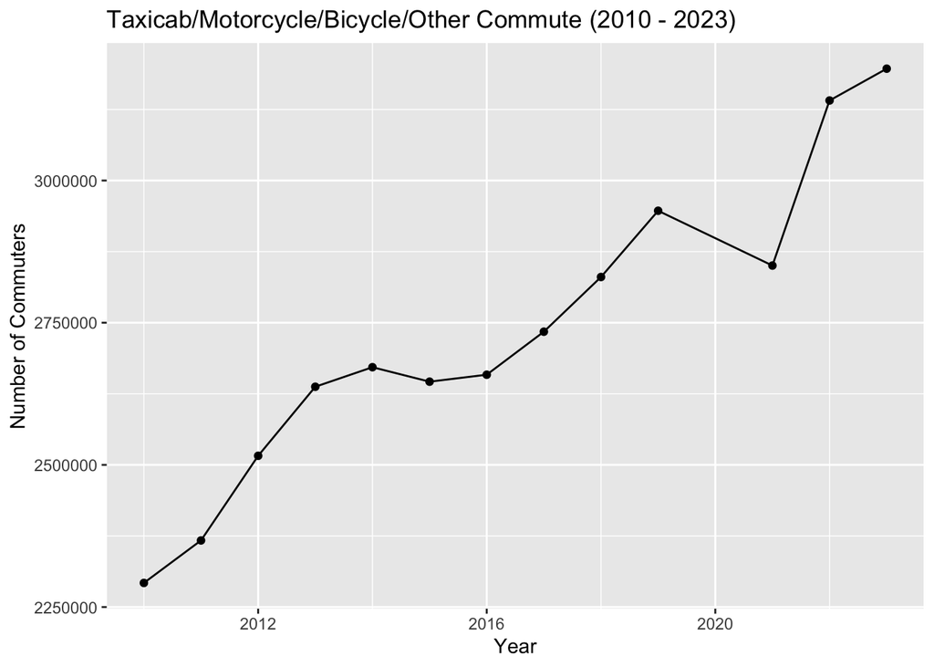

For the subset of commuters who used a taxicab, motorcycle, bicycle, or other to commute to work, the number of commuters grew at a somewhat steady rate over time. We can see more variability to this trend over time, although we still do see a general increase in the graph. We see less of a sharp drop in this mode of transportation in 2021, although still a drop. This could be due to a number of factors, such as this subset of the population continuing to need their mode of transportation throughout the COVID-19 pandemic.

The overall correlation between these commuters and time (years) is very strong, with a correlation coefficient of 0.9598, indicating a very strong relationship between time and the growth of commuters throughout the time period. The previous graphs we have seen had a less strong correlation over the whole time period, but likely due to the more minor of a drop we see in this data for the year 2021, our overall data is less skewed hence more correlated.

```r
cor(data$`TMBO T`, data$Year)
```

```
## [1] 0.9598197
```

Before the pandemic, the correlation between commuters and time was also very strong, with a coefficient of 0.9543. After the pandemic, the correlation remained strong, with a coefficient of 0.9314. This shows that before and after the COVID-19 pandemic, the number of commuters who used a taxicab, motorcycle, bicycle, or other to commute to work in the U.S. has been growing and is strongly correlated with time.

```r
cor(pre_covid$`TMBO T`, pre_covid$Year)
```

```
## [1] 0.9543693
```

```r
cor(post_covid$`TMBO T`, post_covid$Year)
```

```
## [1] 0.931431
```

## 3.7 Worked From Home Commute to Work Distribution

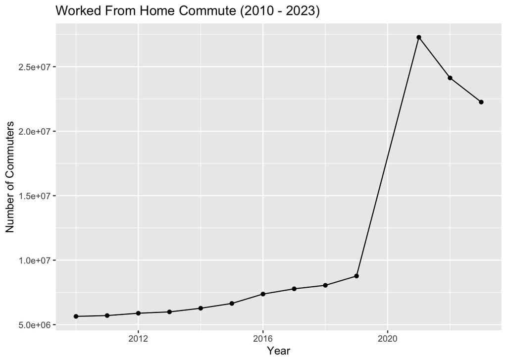

For the subset of commuters who work from home, the number of commuters grew at a somewhat steady rate over time before the pandemic, with a drop after the pandemic. We can see that WFH, although growing, was much smaller before versus after the pandemic. At the peak the COVID-19 pandemic, there was a sharp increase in people working from home. We are now in a period of companies slowly decreasing their WFH employees.

The overall correlation between these commuters and time (years) is moderately strong, with a correlation coefficient of 0.8262. This shows that overall, the number of people working from home in the U.S. has been growing.

```r
cor(data$`WFH T`, data$Year)
```

```
## [1] 0.8262338
```

Before the pandemic, the correlation between commuters and time was very strong, with a coefficient of 0.9691. After the pandemic, the correlation became negative and still strong with a coefficient of -0.9894. This shows that before the COVID-19 pandemic, the number of people working from home in the U.S. was growing, and after the pandemic this mode of transportation has started decreasing heavily with the rise of companies stopping and slowing working from home culture.

```r
cor(pre_covid$`WFH T`, pre_covid$Year)
```

```
## [1] 0.9690568
```

```r
cor(post_covid$`WFH T`, post_covid$Year)
```

```
## [1] -0.9893943
```

## 3.8 Commute to Work Distribution Over Time by Mode of Transportation

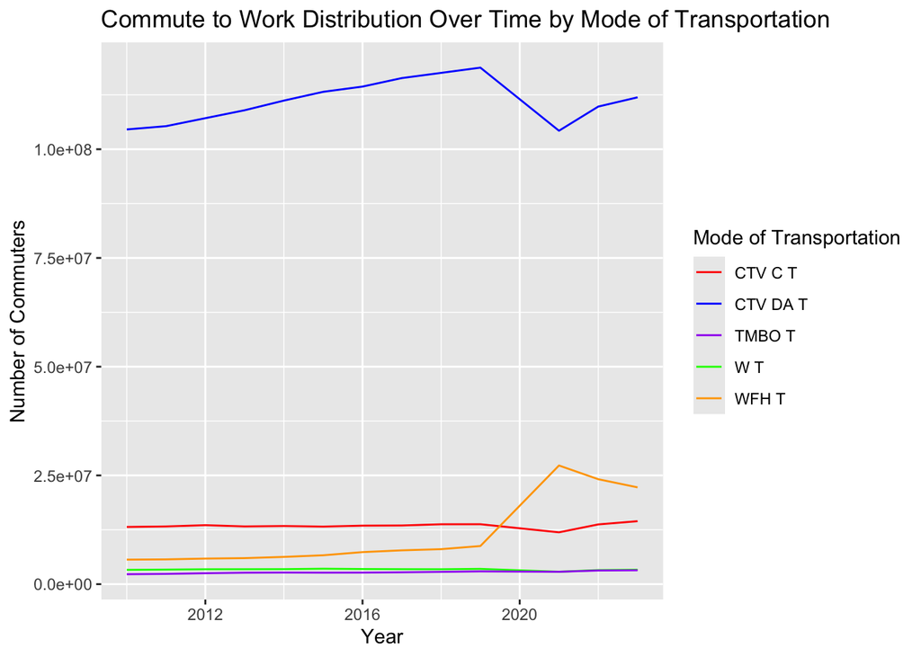

**Key**

- Total: Total Sample Collected
- CTV DA T: Car/Truck/Van (Drove Alone) Total
- CTV C T: Car/Truck/Van (Carpooled) Total
- W T: Walked Total
- TMBO T: Taxicab/Motorcycle/Bicycle/Other Total
- WFH T: Worked From Home Total

*Note: The term “Total” signifies the aggregate number of individuals represented in the dataset for each respective year.*

From this graph, we can see each of the 5 different modes of transportation broken down by color. Here, we can see that the most frequent mode of transportation in the U.S. is using a car/van/truck (driving alone). Before the pandemic, using a car/van/truck (carpooling) would have been the second most common mode of transportation, but after the pandemic now working from home is the second most common mode of transportation, with carpooling moved to the third most common mode of transit. Before the pandemic WFH was the third most common mode of transit. Walking and taxicab/motorcycle/bicycle/other come in close for fourth and fifth, but overall walking is slightly more common than taxicab/motorcycle/bicycle/other is for a mode of transit to work. This trend has remained the same before and after the pandemic.

# 4 Conclusion

In conclusion, the U.S. relies more heavily on cars and individual modes of transportation (private transit) compared to many other developed nations, which can be seen in the data through the car/truck/van (driving alone) mode of transport being the most common both before and after the pandemic. There are many factors as to why the U.S. is more reliant on individual/private transportation than other nations; the expansion of urban cities, infrastructure designed around individual cars, limited public transportation, and the cultural usage of cars in the states are some examples.

However, there’s a shift in the U.S. towards different modes of transportation beyond private vehicles. For example, we firstly can see that after the pandemic, commuters who drive alone decreased significantly and hasn’t reached its peak levels prior to the pandemic. This shows that after the pandemic, less people are driving alone versus prior to the pandemic. We also see that carpooling saw significant growth before the pandemic, with a correlation coefficient with time (years) of 0.7748, rising to 0.9718 after the pandemic, showing that carpooling is gaining over time. Walking to work has also grown, with a pre-pandemic correlation coefficient of 0.7159, increasing to 0.9385 post-pandemic, indicating an upward trend. Those commuting using taxicab/motorcycle/bicycle/other has strong growth, with a correlation coefficient of 0.9544 pre-pandemic and 0.9314 post-pandemic, showing that this mode of transit continues to rise. Working from home, which had been gradually increasing before the pandemic (correlation coefficient of 0.9691), saw a dramatic increase between 2019 and 2021, jumping from roughly 8.8 million to roughly 27.3 million people due to the COVID-19 pandemic. However, as we move back to in-person work, there’s a significant decline in WFH, reflected by a post-pandemic correlation coefficient of -0.9894, indicating that WFH is rapidly decreasing over time.

# 5 Flexadashboard

**[Link to Flexadashboard](https://lilyclaire.shinyapps.io/R_Project_Flexadashboard_Link/)**

[Source on how to link Flexadashboard](https://www.andrewheiss.com/blog/2020/01/01/flexdashboard-dynamic-data/)

# 6 Biography

Hello! I’m Lily Claire (or LC) Gibson-Grossmann. I recently graduated from Clemson University with bachelor’s degrees in Mathematics and Secondary Education. Currently, I am pursuing my Master’s in Data Science and Analytics, also at Clemson. After completing two successful summer internships, I am excited to begin my career as a Quantitative Analyst at Bank of America in July 2025. I have a passion for learning, personal growth, helping others, and making positive contributions to my community.

While I don’t have much experience living in a major city, this past summer I lived in Huntersville, North Carolina, and commuted each weekday to Charlotte. This experience gave me a new perspective on different modes of transportation, as I used the bus for my daily commute. I developed a greater appreciation for transit in general and began reflecting on why the U.S. has not prioritized expanding different modes of transportation systems instead of just private transportation. Diversifying the transportation we use offers many benefits, including reducing traffic, lowering negative environmental impacts, and increasing economic equity. At the same time, I became intrigued by the growing shift away from remote work. With many companies scaling back work-from-home options after the pandemic, I became curious about the overall trends in remote work, especially how these patterns have evolved over time.

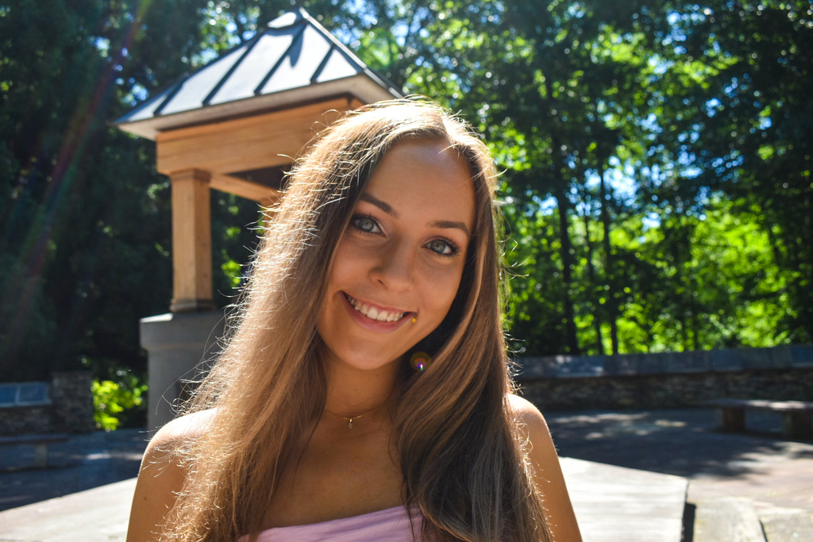

# 7 References

Andrew Heiss (2020). Create a dynamic dashboard with R, flexdashboard, and Shiny. https://www.andrewheiss.com/blog/2020/01/01/flexdashboard-dynamic-data/

U.S. Census Bureau. Experimental Data Products from the American Community Survey. https://www.census.gov/programs-surveys/acs/data/experimental-data.html

U.S. Bureau of Labor Statistics. Questions and Answers: American Community Survey and Local Area Unemployment Statistics Program. https://www.bls.gov/lau/acsqa.htm

U.S. Census Bureau. Top Questions About the American Community Survey. https://www.census.gov/programs-surveys/acs/about/top-questions-about-the-survey.html

U.S. Census Bureau (2022). Means of Transportation to Work by Vehicles Available. American Community Survey 1-Year Estimates, Table B08141. https://data.census.gov/table/ACSDT1Y2022.B08141